# Upper Gila Watershed Bayesian Network Results Analysis

Lauren Victoria Jaramillo, UNM (alwayslo@unm.edu)

4/5/2019

This R notebook is used to used to analyze the results from the BN model.

### Result Analysis

```r
rm(list=ls())
library("bnlearn")
library("readr")
library("Rgraphviz")
library("xts")
library("prob")
library("TTR")
library("bigmemory")
library("zoo")
library("raster")
library("sp")
library("rgdal")
library("rasterVis")
library("ggplot2")
library("rgdal")
# library("dplyr")
library("methods")
require("BiocGenerics")
require("graph")
library("sf")
library("maps")
library("RColorBrewer")
library("stringi", lib.loc="/Library/Frameworks/R.framework/Versions/3.4/Resources/library")
getwd()
```

```
[1] "/Users/lohebert/GilaBN"
```

Load and plot all flow scenarios modeled.

```r
hydro <- read.csv("data/scenarios_revised.csv", skip=1,header = TRUE)[ ,1:5]
hydro <- setNames(hydro, c("date","natural", "Alt. E","Alt. B","Alt. A"))
hydro$date <-as.Date(hydro$date, format="%m/%d/%Y")
hydro$julian <- format(hydro$date, "%j")
hydro$julian <-stri_replace_all_regex(hydro$julian, "\\b0*(\\d+)\\b", "$1")
hydro$month <- format(hydro$date,"%m")
```

Plots the hydrologic data that is actually used in the model which is governed by the lowest minimum innundation value.

Plots the mean daily flows for all four scenarios (natural,current_operations,combined_operations,combined_operations_AWSA).

```r
meanJulian <- data.frame()
for (i in 1:length(unique(hydro$julian)))
{ julian_i <- colMeans(hydro[hydro$julian== i,2:5])
  meanJulian <- rbind(meanJulian, julian_i)}
meanJulian <- cbind( 1:length(unique(hydro$julian)),meanJulian)
meanJulian<-setNames(meanJulian, c("julian","natural", "Alt_E","Alt_B","Alt_A"))
meanJulian<-na.omit(meanJulian)
ggplot(meanJulian, aes(x=julian))+
  geom_line(aes(y = natural, color = "natural"),linetype = 1)+
  geom_line(aes(y = Alt_E, color = "blue"),linetype = 1)+
  geom_line(aes(y = Alt_B, color = "green"),linetype = 2)+
  geom_line(aes(y = Alt_A, color = "orange"),linetype = 4)+
  xlab("Julian day")+
  ylab("flow (cfs)")+
  ggtitle("Upper Gila Mean Daily Flow\n April to September 1936 - 2017")+
  theme(plot.title = element_text(hjust = 0.5))+
  labs(color="scenario")+
  geom_hline(yintercept = 1000)
```

```
Error: Aesthetics must be either length 1 or the same as the data (1): y, colour, x
```

Plots the one standard deviation above the mean daily flows for all four scenarios (natural,current_operations,combined_operations,combined_operations_AWSA).

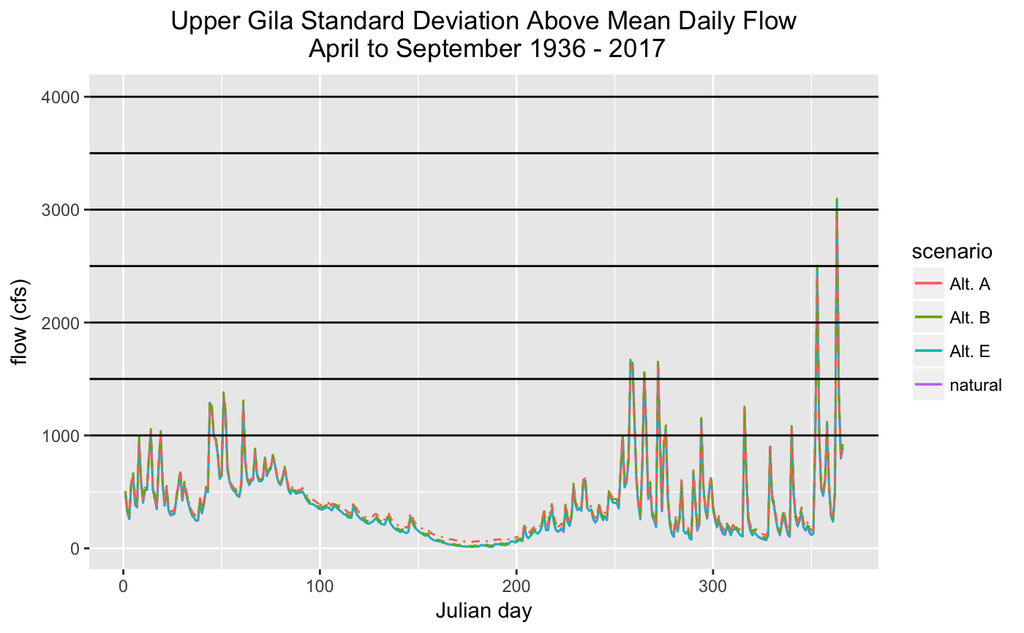

```r
sigma1Julian <- data.frame()
for (i in 1:length(unique(hydro$julian)))
{ julian_i <- colMeans(hydro[hydro$julian== i,2:5])+ colStdevs(hydro[hydro$julian== i,2:5])
  sigma1Julian <- rbind(sigma1Julian, julian_i)}
sigma1Julian <- cbind( 1:length(unique(hydro$julian)),sigma1Julian)
sigma1Julian<-setNames(sigma1Julian, c("julian","natural", "Alt_E","Alt_B","Alt_A"))
sigma1Julian<-na.omit(sigma1Julian)
ggplot(sigma1Julian, aes(x=julian))+
  geom_line(aes(y = natural, color = "natural"),linetype = 1)+
  geom_line(aes(y = Alt_E, color = "Alt. E"),linetype = 1)+
  geom_line(aes(y = Alt_B, color = "Alt. B"),linetype = 2)+
  geom_line(aes(y = Alt_A, color = "Alt. A"),linetype = 4)+
  xlab("Julian day")+
  ylab("flow (cfs)")+
  ggtitle("Upper Gila Standard Deviation Above Mean Daily Flow\n April to September 1936 - 2017")+
  theme(plot.title = element_text(hjust = 0.5))+
  labs(color="scenario")+
  geom_hline(yintercept = c(1000, 1500, 2000, 2500, 3000, 3500, 4000))
ggsave("meandailyflow.tiff", units="in", width=5, height=4, dpi=900, compression = 'lzw')
```

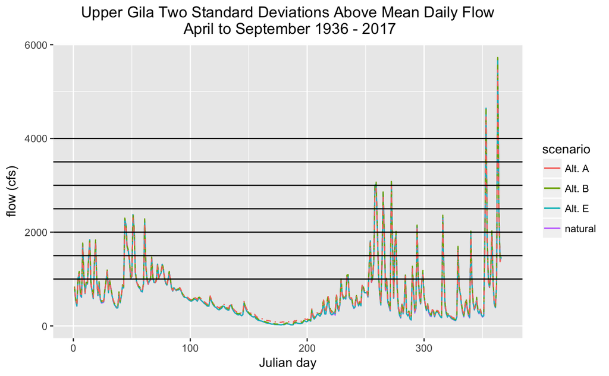

```r
sigma2Julian <- data.frame()
for (i in 1:length(unique(hydro$julian)))
{ julian_i <- colMeans(hydro[hydro$julian== i,2:5])+ 2*colStdevs(hydro[hydro$julian== i,2:5])
  sigma2Julian <- rbind(sigma2Julian, julian_i)}
sigma2Julian <- cbind( 1:length(unique(hydro$julian)),sigma2Julian)
sigma2Julian<-setNames(sigma2Julian, c("julian","natural", "Alt_E","Alt_B","Alt_A"))
sigma2Julian<-na.omit(sigma2Julian)
ggplot(sigma2Julian, aes(x=julian))+
  geom_line(aes(y = natural, color = "natural"),linetype = 1)+
  geom_line(aes(y = Alt_E, color = "Alt. E"),linetype = 1)+
  geom_line(aes(y = Alt_B, color = "Alt. B"),linetype = 2)+
  geom_line(aes(y = Alt_A, color = "Alt. A"),linetype = 4)+
  xlab("Julian day")+
  ylab("flow (cfs)")+
  ggtitle("Upper Gila Two Standard Deviations Above Mean Daily Flow\n April to September 1936 - 2017")+
  theme(plot.title = element_text(hjust = 0.5))+
  labs(color="scenario")+
  geom_hline(yintercept = c(1000, 1500, 2000, 2500, 3000, 3500, 4000))
```

Plot only flows greater than 1000 cfs. Visualize data being used. (not working)

```r
naturalHI <- hydro[hydro[2] >= 1000,]
scenario1HI <- hydro[hydro[3] >= 1000,]
scenario2HI <- hydro[hydro[4] >= 1000,]
scenario3HI <- hydro[hydro[5] >= 1000,]
mean_qHI <- data.frame()
for (i in 1:length(unique(scenario3HI$julian)))
{ julian_i <- colMeans(scenario3HI[scenario3HI$julian== i,2:5])
  mean_qHI <- rbind(mean_qHI, julian_i)}
mean_qHI <- cbind( 1:length(unique(scenario3HI$julian)),mean_qHI)
mean_qHI<-setNames(mean_qHI, c("julian","natural", "Alt_E","Alt_B","Alt_A"))
mean_qHI<-na.omit(mean_qHI)
ggplot(mean_naturalHI, aes(x=julian))+
  geom_line(aes(y = natural, color = "natural"),linetype = 1)+
  geom_line(aes(y = Alt_E, color = "Alt. E"),linetype = 1)+
  geom_line(aes(y = Alt_B, color = "Alt. B"),linetype = 2)+
  geom_line(aes(y = Alt_A, color = "Alt. A"),linetype = 4)+
  xlab("Julian day")+
  ylab("flow (cfs)")+
  ggtitle("Upper Gila Mean Daily Flow\n April to September 1936 - 2017")+
  theme(plot.title = element_text(hjust = 0.5))+
  labs(color="scenario")+
  geom_hline(yintercept = 1000)
```

```
Error in ggplot(mean_naturalHI, aes(x = julian)) :
  object 'mean_naturalHI' not found
```

```r
q_diff <- cbind(hydro$julian, hydro[2]-hydro[3],hydro[2]-hydro[4],hydro[2]-hydro[5])
q_diff <- setNames(q_diff, c("julian", "Alt. E","Alt. B","Alt. A"))
meanJulianDiff <- data.frame()
for (i in 1:length(unique(q_diff$julian)))
{ julian_i <- colMeans(q_diff[q_diff$julian== i,2:4])
  meanJulianDiff <- rbind(meanJulianDiff, julian_i)}
meanJulianDiff <- cbind( 1:length(unique(q_diff$julian)),meanJulianDiff)
meanJulianDiff<-setNames(meanJulianDiff, c("julian", "Alt. E","Alt. B","Alt. A"))
meanJulianDiff<-na.omit(meanJulianDiff)
ggplot(meanJulianDiff, aes(x=julian))+
  geom_line(aes(y = natural, color = "natural"),linetype = 1)+
  geom_line(aes(y = Alt_E, color = "Alt. E"),linetype = 1)+
  geom_line(aes(y = Alt_B, color = "Alt. B"),linetype = 2)+
  geom_line(aes(y = Alt_A, color = "Alt. A"),linetype = 4)+
  geom_vline(xintercept = 92, linetype="dotted",  color = "black", size=0.5)+
  geom_vline(xintercept = 274, linetype="dotted",  color = "black", size=0.5)+
  xlab("Julian day")+
  ylab("diverted flow (cfs)")+
  ggtitle("Upper Gila Mean Daily Diverted Flow\n April to September 1936 - 2017")+
  theme(plot.title = element_text(hjust = 0.5))+
  labs(color="scenario")
```

```
Error in FUN(X[[i]], ...) : object 'natural' not found
```

Load scenario results for site 2 (Middle) to be used for analysis.

```r
r_cells_natural_s2 <- read.csv(file ="/Users/lohebert/GilaBN/output/natural_s2_q_cells_recruit.csv", header=TRUE, sep=",",
                               col.names =  c("cell","flow","bin","recruit_q","recruit"))
r_cells_scenario1_s2 <-read.csv(file ="/Users/lohebert/GilaBN/output/scenario1_s2_q_cells_recruit.csv", header=TRUE, sep=",",
                                col.names = c("cell","flow","bin","recruit_q","recruit"))
r_cells_scenario2_s2 <- read.csv(file ="/Users/lohebert/GilaBN/output/scenario2_s2_q_cells_recruit.csv", header=TRUE, sep=",",
                                 col.names = c("cell","flow","bin","recruit_q","recruit"))
r_cells_scenario3_s2 <- read.csv(file ="/Users/lohebert/GilaBN/output/scenario3_s2_q_cells_recruit.csv", header=TRUE, sep=",",
                                 col.names = c("cell","flow","bin","recruit_q","recruit"))
r_cells_s2 <- data.frame(cbind(r_cells_natural_s2[,1],r_cells_natural_s2[,5],r_cells_scenario1_s2[,5],r_cells_scenario2_s2[,5],
                               r_cells_scenario3_s2[,5]))
colnames(r_cells_s2) <- c("cell","natural","Alt. E","Alt. B","Alt. A")
r_prob_natural_s2 <- read.csv(file ="/Users/lohebert/GilaBN/output/natural_s2_recruit_prob.csv", header=TRUE, sep=",")
r_prob_scenario1_s2 <-read.csv(file ="/Users/lohebert/GilaBN/output/scenario1_s2_recruit_prob.csv", header=TRUE, sep=",")
r_prob_scenario2_s2 <- read.csv(file ="/Users/lohebert/GilaBN/output/scenario2_s2_recruit_prob.csv", header=TRUE, sep=",")
r_prob_scenario3_s2 <- read.csv(file ="/Users/lohebert/GilaBN/output/scenario3_s2_recruit_prob.csv", header=TRUE, sep=",")
r_prob_s2 <- cbind(r_prob_natural_s2[,2], r_prob_scenario1_s2[,2],r_prob_scenario2_s2[,2],r_prob_scenario3_s2[,2])
colnames(r_prob_s2)<- c("natural","Alt. E","Alt. B","Alt. A")
rownames(r_prob_s2)<- c("bin_1", "bin_2", "bin_3", "bin_4", "bin_5","bin_6","bin_7","bin_8","bin_9", "bin_10", "bin_11", "bin_12", "bin_13","bin_14","bin_15")
```